# Leagues of Legends Statistics Report

Kai, Michael, Rajeev, Wenyi

11/29/2020

## Summary

The domain of our team is League of Legends, an iconic MOBA game that has over 115 millions players from all around the world. The fun and excitement of this game allows players to never get tired of it as it continues to evolve every season. In recent years, with the development and popularity of e-sports, the official Leagues of Legends “Worlds” competition has become one of the most viewed online gaming events in history. Thus, in this team project, with our team’s passion and interests, we focus on analyzing the data set of official League of Legends competitions, day-to-day games, and character information to determine the various insights about the game itself. While initially we wanted to answer a different variety of questions, we found that the data available to us led us to make slight modifications to our initial questions. The three data sets that we end up utilizing for our analysis are:

> Professional League of Legends match statistics [found here](https://www.kaggle.com/xmorra/league-of-legends-world-championship-2019)

> Massive EUW Data Set of League information for Average Player Statistics [found here](https://www.kaggle.com/datasnaek/league-of-legends)

> League of Legends Champion Data from Riot’s API [found here](https://www.kaggle.com/uskeche/leauge-of-legends-champions-dataset)

## Summary Table: Class Information

In League of legends, there are many different roles a player can choose from when picking their champion. In the competitions, each of the classes bring unique benefits to players based their different characteristics. Here, we summarized some main information regarding character classes. For example, class Mage-Marksman can cause the highest damage where a class like a Tank has the Strongest defensive capabilities. As for mobility, the Mage-Assasin class has the most flexibility and the highest ability to maneuver the map. With that, the Mage-Assasin class is the most difficult class to master, while the Tank class is generally the easiest class to play. We also provide the summary data about each classes with their characteristics.

| Class | Avg Damage | Avg Tankiness | Avg Mobility | Avg Difficulty |
| --- | --- | --- | --- | --- |
| Assasin | 2.923077 | 1.076923 | 2.307692 | 2.000000 |
| Mage | 2.827586 | 1.103448 | 1.344828 | 2.103448 |
| Mage-Assasin | 2.833333 | 1.333333 | 2.666667 | 2.666667 |
| Mage-Marksman | 3.000000 | 1.000000 | 2.000000 | 2.000000 |
| Mage-Support | 2.250000 | 1.000000 | 1.250000 | 1.500000 |
| Mage-Warrior | 2.571429 | 2.285714 | 1.857143 | 2.142857 |
| Marksman | 2.947368 | 1.105263 | 1.789474 | 1.894737 |
| Support | 1.300000 | 1.200000 | 1.700000 | 1.600000 |
| Tank | 1.500000 | 2.875000 | 1.375000 | 1.250000 |
| Tank-Support | 1.166667 | 2.500000 | 1.000000 | 1.833333 |
| Tank-Warrior | 2.222222 | 2.666667 | 1.555556 | 1.444444 |
| Warrior | 2.322581 | 2.161290 | 1.838710 | 1.838710 |
| Warrior-Assasin | 3.000000 | 2.000000 | 2.500000 | 2.000000 |

## Chart 1: Objective Control and Win Percentages

Throughout each match, there are things called “objectives” that players attempt to control and obtain which (usually) bring benefits for their entire time. An example of this would be getting the **First Blood**, which gives bonus gold to the first team that obtains it. This is, of course, one of many different “first” objectives a team can obtain in the game, where some others include - first inhibitor, first tower, first Baron, first Dragon, first scuttle, etc. These are all important factors to consider into the game as objective control helps propogate larger leads against the enemy team. Visualized below are a few of the more relevant “first” objectives and how they impact a team’s probability of winning.

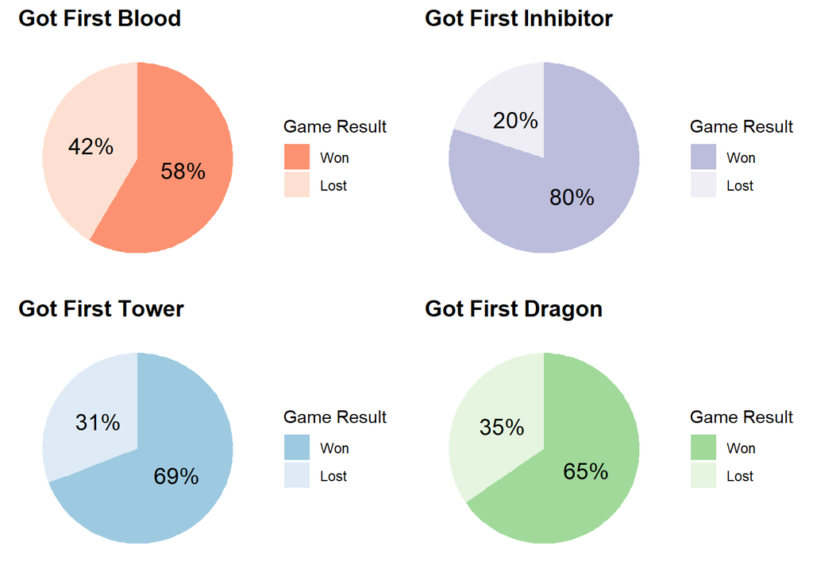

As the pie charts indicate above, *all* of these objectives positively impact a team’s probability of winning the game. Of these, the least impactful appears to be getting First Blood - which makes sense given the fact that the bonuses of getting First Blood have minimal impact on other team other than a minor gold advantage. That being said, however, getting First Blood can be an indicator of a skill gap between teams, which could be a factor as to why it has a positive correlation. The most impactful of the objectives, as indicated above, is obtaining first Inhibitor. In fact, the visualization shows that 80% of the games in our data set were won by the team that obtained the first Inhibitor. As for the rest, both objectives of obtaining first Tower and obtaining first Dragon appear to have a positive correlation with winning the game, having 69% and 65% win rates respectively. Furthermore, we included this visualization in order to represent the ultimate objective of the game: to secure large territorial victories and gold leads. We decided to break this up into four charts representing various objectives because it can provide a lot of insight as to where players should focus their attention, especially in a game with so many things to keep track of. As a result, one take-away that you could get from this chart is that, regardless of how many kills or CS the other team has, if you are able to secure things like towers or inhibitors you are statistically giving yourself a better chance of winning. We felt that faceted pie charts could communicate this the best as they are easily interpretable and are color coded to represent various important objectives.

## Chart 2: Scatter Plots regarding Wards and Vision Score

With that, in professional matches, wards are a very important factor that may determine the winners and losers. It refers to a deployable unit that removes the fog of war in a certain area of the map. Then, each member of the team can clearly see where their teammates are, and can help them better place battle strategy. Generally, the more wards a team has, the higher probability of them winning. In the scatter plot, we split the winning and losing teams in professional League of Legends play and analyzed their relationship between the wards that each team place in battleground and their number of deaths.

*(Note: 0 represents losing the game, 1 represents winning the game)*

[interactive chart not shown]

From the right-hand table, it shows that the number of wards in most win teams is concentrated on interval [100, 150]. Whereas, on the left-hand table, the number of wards in most losing teams is mainly between [0, 150]. **The different intervals showed that the more wards the teams have, the more possibility they will win the game.**

We decided to visualize ward placements because, within the game and espescially within lower ELOs of League of Legends, vision score and warding is often looked over as irrelevant. However, as you get into higher levels of play, wards and vision control become *significantly* more important. We felt that a scatterplot would be the best representation of this data as, in professional matches, each individual game matters and this allows us to see if there was any positive or negative correlation between the number of wards placed, the number of deaths that occurred, and if that was part of the winning or losing team. It’s important to note, however, that we can’t draw direct insights based off of warding tendencies as, with the highest levels of play, it’s unlikely that a single factor would have a huge sway on the games.

## Chart 3: Professional Ban Rates

In each match, players from both teams vote to ban a certain champion from being played in the match. Voting for each ban is done 5 times for both teams but teams can also choose to not ban a champion during one of these phases. Then, players choose what champions to play. These votes exist because League of Legends has over **150 different champions** to play from and each have their respective abilities that make them unique. By providing bans, teams can ensure they won’t have to play against against *certain champions* that are strong with the enemy’s team compositions or champions that *counter* their own champions. In the graph, we were able to obtain the top ten banned champions during the **LCS 2019 Summer Season** by counting each banned champions selected for each team ban and ranking the top ten.

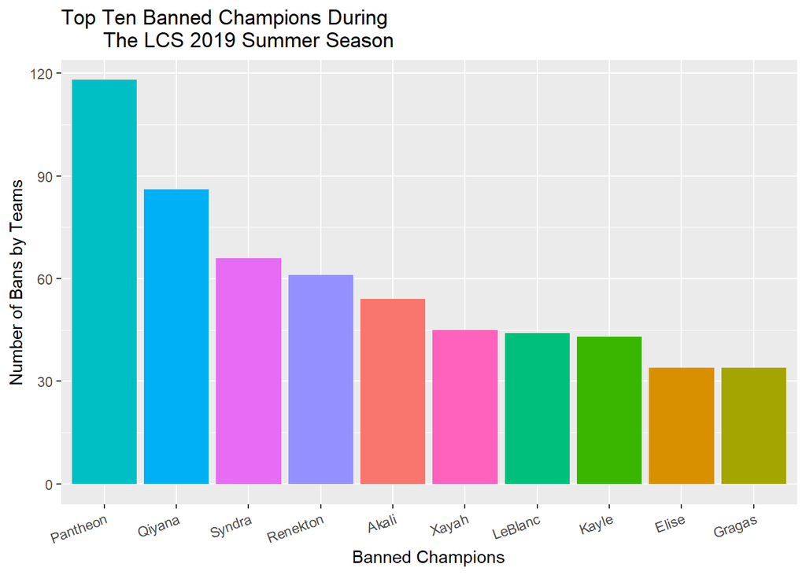

As seen in the graph, **Pantheon** seems to be the most banned champion from all teams that participated during the LCS 2019 Summer Series, with **Qiyana** coming in second. The reason for Pantheon being the most banned champion during the series was because players knew how overpowered Pantheon was in matches in 2019. Because of his versatility as a champion, teams were better off banning him instead of going against him. To read more about why he was banned, [click here.](https://www.invenglobal.com/articles/9417/worlds-2019-why-pantheon-was-banned-for-100-of-group-stage) We chose to use bar graphs to represent the most banned champions because it was an easy way to visualize which champions were the most banned by looking at the bar that was the highest as it gradually goes down the rest of the ranks of the top ten banned champions.